## 二叉树问题

懵逼树上懵逼果，懵逼树下只有我。。。

- root.val是该节点的值。
- root则相当于指向该节点的指针。
- root.left, root.right指向其左右节点的位置

val=values left,right就是位置

二叉树节点的定义

```r
# Definition for a binary tree node.
class TreeNode(object):
    def __init__(self, x):
        self.val = x
        self.left = None
        self.right = None
```

还是得结合二叉树主要解决了什么实际的问题

树为啥这么好用

[知乎](https://zhuanlan.zhihu.com/p/63419145)

### 相同的树问题

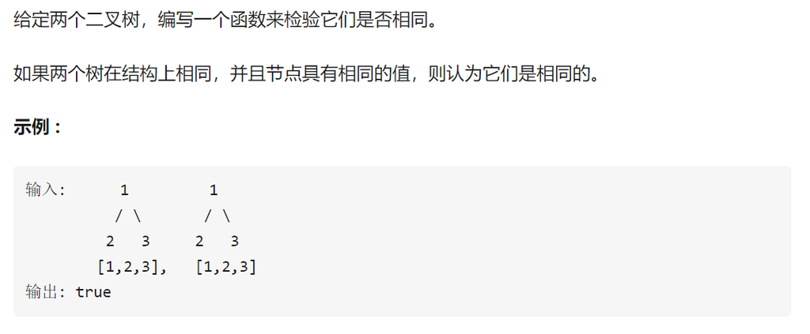

相同的树

判断两个树是否为相同的树

解题思路：两个树的结构相同，节点相同则相同,或者都为空也相同 递归 假入有2棵树p,q

```r
class Solution(object):
    def isSameTree(self, p, q):

        if p is None and q is None:
            return True
        if p is not None and q is not None:
            return p.val==q.val and self.isSameTree(p.left,q.left) and self.isSameTree(p.right,q.right)
        return False
```

### 对称二叉树

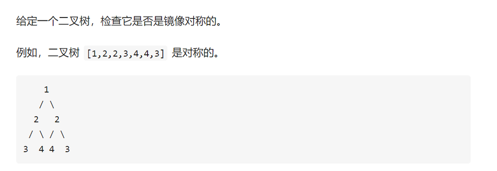

对称的树

> 首先判断头结点是否为空。然后**将根节点的左右两个节点假设成两个独立的树**，如果左右两个树都为空，返回True。然后看左子树的左结点和右子树的右结点、左子树的右结点和右子树的左结点是否相同，都相同返回True.

```r
class Solution(object):
    def isSymmetric(self, root):

        if root is None:
            return True
        return self.isSymmetricTree(root.left,root.right)
    def isSymmetricTree(self,left,right):
        if left is None and right is None:
            return True
        if left is None or right is None or left.val != right.val:
            return False
        return self.isSymmetricTree(left.left,right.right) and self.isSymmetricTree(left.right,right.left)
```

### 二叉树的最大深度

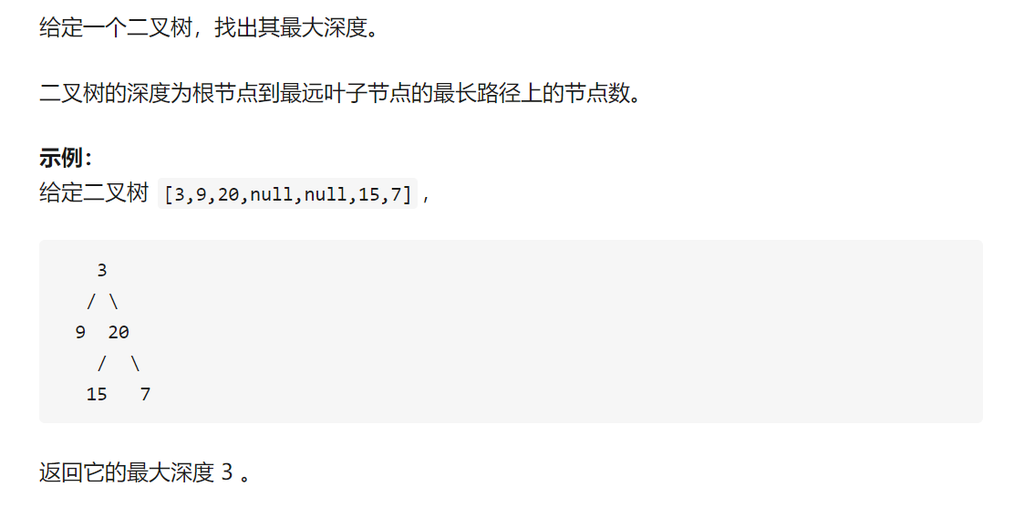

二叉树的深度为根节点到最远叶子节点的最长路径上的节点数。

```r
class Solution(object):
    def maxDepth(self, root):

        if root is None:
            return 0
        else:
            return max(self.maxDepth(root.left),self.maxDepth(root.right))+1
```

### 二叉树的最小深度

最小深度是从根节点到最近叶子节点的最短路径上的节点数量。

```r
class Solution(object):
    def minDepth(self, root):

        if root is None:
            return 0
        if root.left and root.right:
            return min(self.minDepth(root.left),self.minDepth(root.right))+1
        else:
            return max(self.minDepth(root.left),self.minDepth(root.right))+1 #根节点只有一个节点的时候
```

### 二叉树的层次遍历

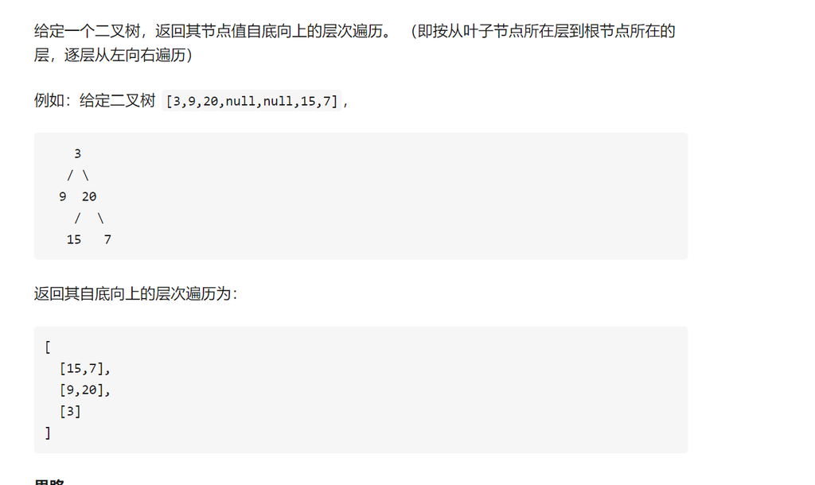

给定一个二叉树，返回其节点值自底向上的层次遍历。（即按从叶子节点所在层到根节点所在的层，逐层从左向右遍历）

定义两个数组，一个level的，一个level装节点的

```r
class Solution(object):
    def levelOrderBottom(self, root):

        if root is None: #根节点不为空
            return []

        result,current = [],[root] #当前节点在root

        while current:
            next_level,vals = [], []
            for node in current:
                vals.append(node.val)
                if node.left:
                    next_level.append(node.left)
                if node.right:
                    next_level.append(node.right)
            current = next_level
            result.append(vals)
        return result[::-1] #从低向上
```

### 将有序数组转化为二叉树

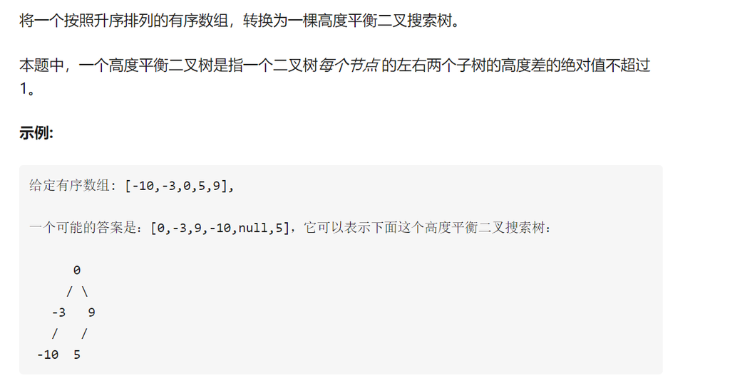

将有序数组转化为二叉树

转换为二叉搜索树

**取有序数组的中间节点作为根节点，将数组分为左右两个部分，对左右两个子数组做相同的操作，递归的实现**。暴力取中间节点为root：递归实现

```r
class Solution:
    def sortedArrayToBST(self, nums: List[int]) -> TreeNode:
        if nums:
            m = len(nums) // 2 中间节点为根节点
            r = TreeNode(nums[m])
            r.left, r.right = map(self.sortedArrayToBST, [nums[:m], nums[m+1:]])
            return r
```

### 平衡二叉树

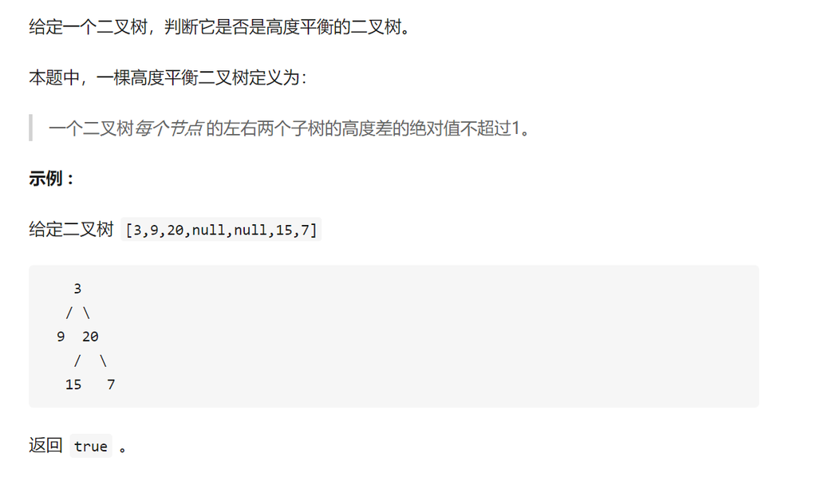

```r
class Solution(object):
    def isBalanced(self, root):

        if root == None:
            return True
        elif abs(self.height(root.left)-self.height(root.right))>1: #高度的绝对值之差大于1，不平衡
            return False
        else:
            return self.isBalanced(root.left) and self.isBalanced(root.right)

    def height(self,root): #判断是否为平衡
        if root == None:
            return 0
        else:
            return max(self.height(root.left),self.height(root.right))+ 1
```

### 路径总和1

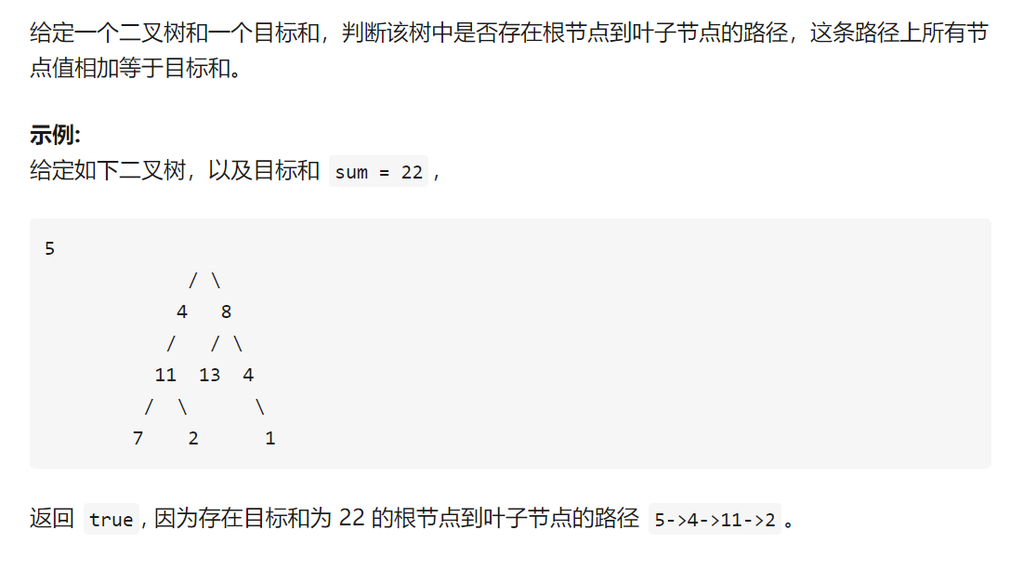

给定一个二叉树和一个目标和，判断该树中是否存在根节点到叶子节点的路径，这条路径上所有节点值相加等于目标和。

**从上到下加起来，最后一个节点的值就等于sum-前面的和，且这个节点是叶子节点。**

```r
class Solution(object):
    def hasPathSum(self, root, sum):

        if root is None:
            return False
        if root.left is None and root.right is None and root.val==sum:
            return True
        else:
            return self.hasPathSum(root.left,sum-root.val) or self.hasPathSum(root.right,sum-root.val)
```

### 翻转二叉树

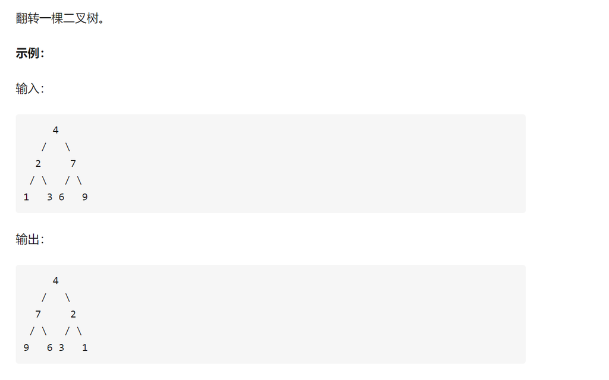

镜面对换

那就是交换左右节点喽

```r
class Solution(object):
    def invertTree(self, root):

        if root is not None:
            root.left,root.right = self.invertTree(root.right),self.invertTree(root.left)
        return root
```

### 公共祖先

二叉搜索树的最近公共祖先

这个不太明白。。

哦哦哦，这是确定了树，按照此题分析就好了，哈哈，看树的结构，左子树均小于根节点的值，右子树均大于根节点的值

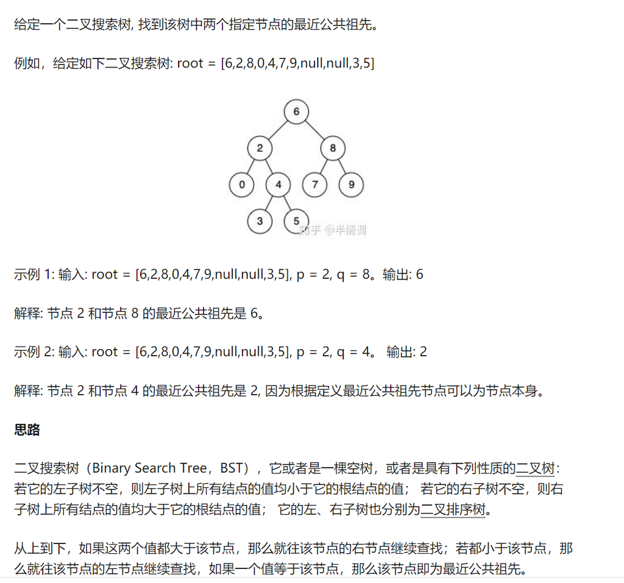

公共祖先描述

```r
# Definition for a binary tree node.
# class TreeNode(object):
#     def __init__(self, x):
#         self.val = x
#         self.left = None
#         self.right = None

class Solution(object):
    def lowestCommonAncestor(self, root, p, q):
        """
        :type root: TreeNode
        :type p: TreeNode
        :type q: TreeNode
        :rtype: TreeNode
        """
        pointer = root
        while pointer:
            if q.val < pointer.val and p.val < pointer.val:
                pointer = pointer.left
            elif q.val > pointer.val and p.val > pointer.val:
                pointer = pointer.right
            else:
                return pointer
```

### 二叉树的所有路径

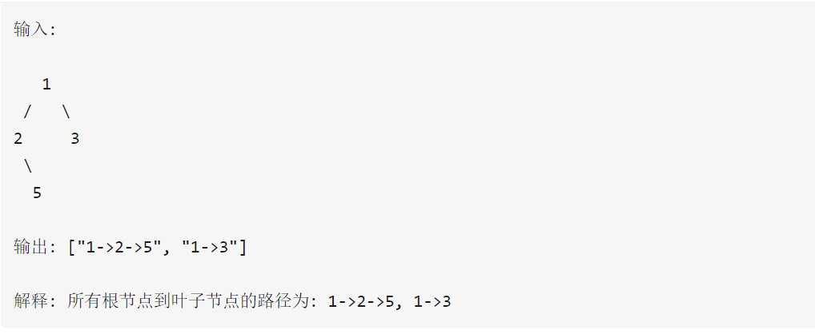

所有路径

```r
class Solution(object):
    def binaryTreePaths(self, root):
        """
        :type root: TreeNode
        :rtype: List[str]
        """
        result = list()
        if root == None:
            return result

        if root.left == None and root.right == None:
            result.append(str(root.val))
            return result # 保存根节点的值

        left = self.binaryTreePaths(root.left)
        for i in range(len(left)):
            result.append(str(root.val) + '->' + left[i]) #遍历一遍左节点

        right = self.binaryTreePaths(root.right) #遍历一遍右节点
        for i in range(len(right)):
            result.append(str(root.val) + '->' + right[i])

        return result
```

### 左叶子之和

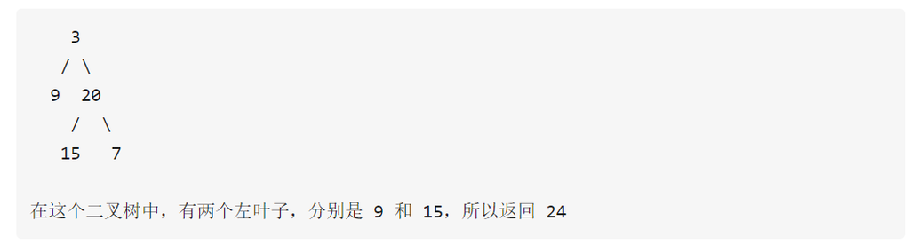

左叶子之和

也就是左子树的叶子节点的值与右子树左叶子叶子节点的值

```r
class Solution(object):
    def sumOfLeftLeaves(self, root):
        """
        :type root: TreeNode
        :rtype: int
        """
        result = 0
        if not root:
            return 0
        if root.left and not root.left.left and not root.left.right:
            result += root.left.val
        return result+self.sumOfLeftLeaves(root.left)+self.sumOfLeftLeaves(root.right)
```

### 路径总和2

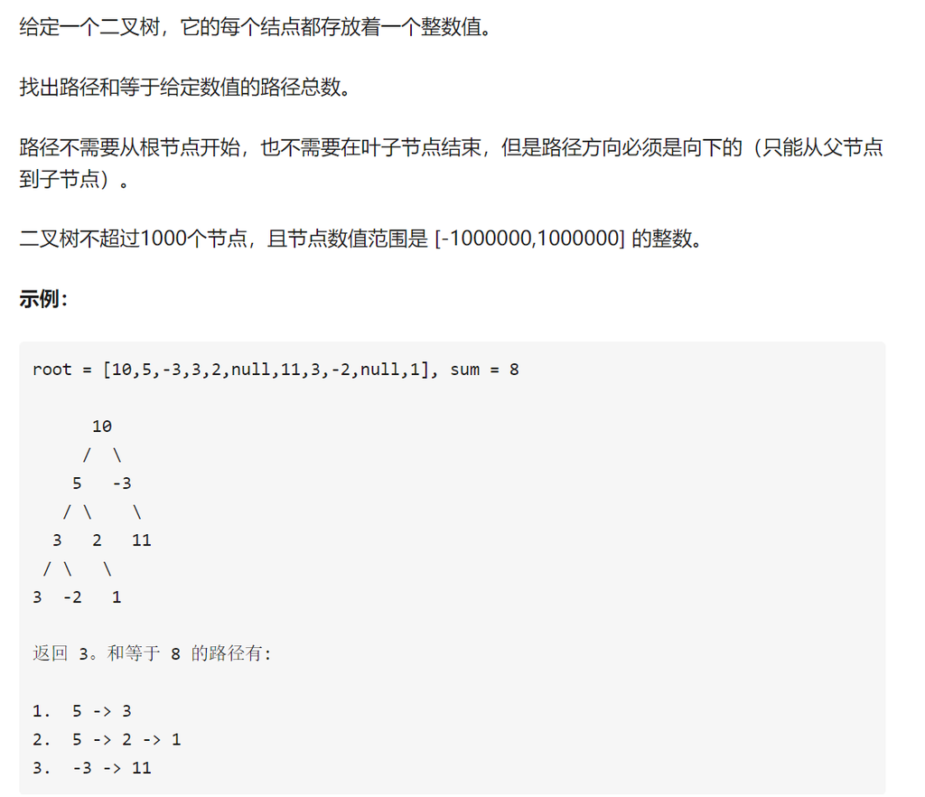

路径总和

```r
class Solution(object):
    def pathSum(self, root, sum):
        """
        :type root: TreeNode
        :type sum: int
        :rtype: int
        """
        if not root:
            return 0
        return self.pathSumFrom(root, sum) + self.pathSum(root.left, sum) + self.pathSum(root.right, sum)

    def pathSumFrom(self, node, sum):
        if not node:
            return 0
        return (1 if node.val == sum else 0) + self.pathSumFrom(node.left, sum - node.val) + self.pathSumFrom(node.right, sum - node.val)
```

## 二叉树的遍历

二叉树这里还是可以多使用一点递归的方法

## 前序遍历

```r
class Solution(object):
    def __init__(self):
        self.res = []
    def preorderTraversal(self, root):
        """
        :type root: TreeNode
        :rtype: List[int]
        """
        if root == None:
            return []
        self.res.append(root.val)#每次遍历到根结点就把它加到队列中
        self.preorderTraversal(root.left)#当有左节点的时候就处理左节点
        self.preorderTraversal(root.right)#当同级没有左节点的时候再处理右节点
        return self.res
```

## 中序遍历

给定一个二叉树，返回它的中序 遍历。

示例:

```r
# Definition for a binary tree node.
# class TreeNode:
#     def __init__(self, x):
#         self.val = x
#         self.left = None
#         self.right = None

class Solution:
    def inorderTraversal(self, root: TreeNode) -> List[int]:
        if root == None: 如果节点不存在
            return []
        left = self.inorderTraversal(root.left)
        right = self.inorderTraversal(root.right)
        return left + [root.val] + right #输出的时候把顺序变一下子
```

## 二叉树的层次遍历

给定一个二叉树，返回其按层次遍历的节点值。 （即逐层地，从左到右访问所有节点）。

例如: 给定二叉树: [3,9,20,null,null,15,7],

[output not shown]

```r
class Solution:
    def levelOrder(self, root: TreeNode) -> List[List[int]]:
        if root == None:
            return []
        layer = [root]  #定义当前层
        res = [] #保存结果的数组
        while len(layer):
            this_res = [] #当前层的结果
            next_l = [] #下一层的结果
            for n in layer:
                this_res.append(n.val)
                if n.left: # 左右孩子都在下一层
                    next_l.append(n.left)
                if n.right:
                    next_l.append(n.right)
            res.append(this_res)
            layer = next_l
        return res
```

## 前序中序后序遍历的另一种写法

```r
class TreeNode:
    def __init__(self, x):
        self.val = x
        self.left = None
        self.right = None
class Solution:
    #前序
    def preorder(self,root,ans=[]):
        if root!=None:
            ans.append(root.val)
        if root.left:
            self.preorder(root.left,ans)
        if root.right:
            self.preorder(root.right,ans)
        return ans

    #中序
    def inorder(self,root,ans=[]):
        # if root.left==None and root.right==None:
        #     ans.append(root.val)
        #     return
        if root.left:
            self.inorder(root.left,ans)
        ans.append(root.val)
        if root.right:
            self.inorder(root.right,ans)
        return ans

    #后序
    def postorder(self,root,ans=[]):
        if root.left:
            self.postorder(root.left,ans)
        if root.right:
            self.postorder(root.right,ans)
        ans.append(root.val)
        return ans
```

## 堆排序

树遍历的思想